# Estimate Donald Trump’s Chance of Re-election

# Part 2. Explore the effect of sentiments delivered in speeches

As we mentioned before, we have already calculated the contributions of 10 sentiments to each speeches. The sentiments we detect here are: anger, anticipation, disgust, fear, joy, sadness, surprise, trust, negative, positive.

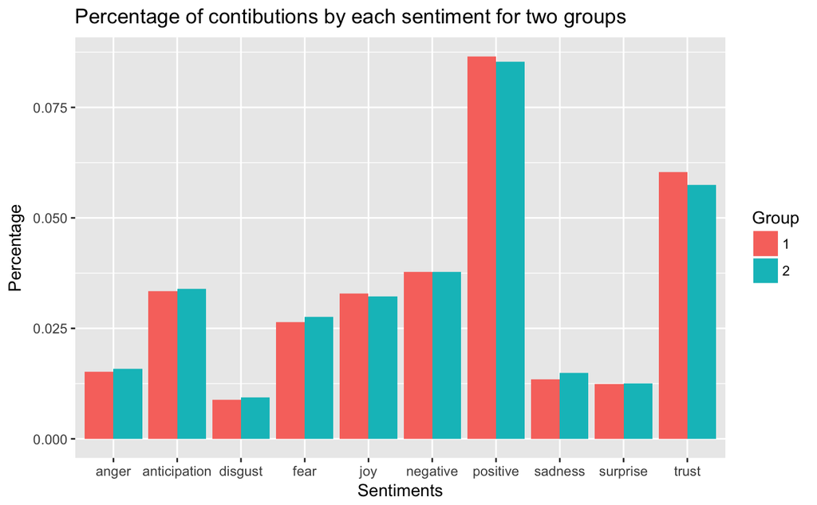

```r
sentiments<-data.frame(sentiment=rep(NA,20),data=rep(NA,20),group=c(rep(1,10),rep(2,10)))
sentiments$sentiment<-rep(colnames(sentence.list_Uni[12:21]),2)
sentiments$data[1:10]<-apply(sentence.list_Uni[12:21],2,mean)
sentiments$data[11:20]<-apply(sentence.list_notUni[12:21],2,mean)
ggplot(data=sentiments, aes(y=data, x=as.factor(sentiment), fill=as.factor(group))) +
  geom_bar(stat="identity", position=position_dodge())+
  ggtitle("Percentage of contibutions by each sentiment for two groups") +
  xlab("Sentiments") + ylab("Percentage")+
  labs(fill = "Group")
```

We are surprised to find that the sentiment constitution in the inaugural speeches of two group are very similar. Therefore, it’s almost impossible to extract the features on sentiment constitution for each group and then put Trump into one of then. However, we can achieve our goal by finding the connenction between Trump and other presidents according to the contributions of sentiments.

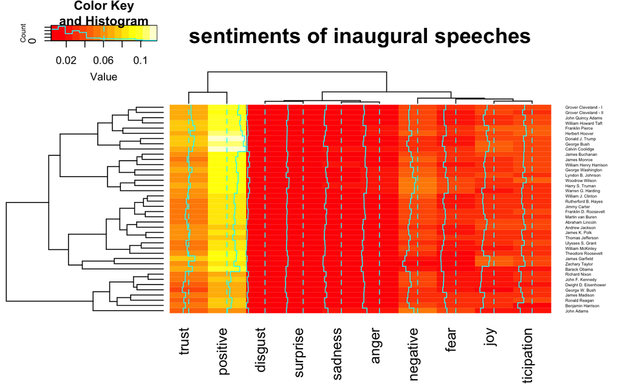

```r
l_by_president<-split(sentence.list,sentence.list$President)
lp<-length(l_by_president)
collect_sentiment<-matrix(rep(NA,lp*10), lp,10)
colnames(collect_sentiment)<-colnames(sentence.list)[12:21]
rownames(collect_sentiment)<-unique(sentence.list$President)
for(i in 1:lp){
  collect_sentiment[i,]<-apply(as.matrix(l_by_president[[i]][,12:21]),2,mean)
}
heatmap.2(collect_sentiment,cexRow = 0.35, main="sentiments of inaugural speeches" )
```